# Joyce Adarkwah

## Project 3 - Loan Modeling

## Objective

Objective of the project is to predict whether a liability customer will buy a personal loan or not, the variables that are most significant and which segment of customers should be targeted more.

## Data Dictionary

- ID: Customer ID
- Age: Customer’s age in completed years
- Experience: #years of professional experience
- Income: Annual income of the customer (in thousand dollars)
- ZIP Code: Home Address ZIP code.
- Family: the Family size of the customer
- CCAvg: Average spending on credit cards per month (in thousand dollars)
- Education: Education Level. 1: Undergrad; 2: Graduate;3: Advanced/Professional
- Mortgage: Value of house mortgage if any. (in thousand dollars)
- Personal_Loan: Did this customer accept the personal loan offered in the last campaign?
- Securities_Account: Does the customer have securities account with the bank?
- CD_Account: Does the customer have a certificate of deposit (CD) account with the bank?
- Online: Do customers use internet banking facilities?
- CreditCard: Does the customer use a credit card issued by any other Bank (excluding All life Bank)?

## Loading and Reviewing Data

```python
#Importing the following libraries will help me read, analyze and visualize the data

import pandas as pd
import numpy as np

import matplotlib.pyplot as plt
import seaborn as sns
```

```python
lmdata = pd.read_csv("Loan_Modelling.csv")
print(f'There are {lmdata.shape[0]} rows and {lmdata.shape[1]} columns.')
```

```
There are 5000 rows and 14 columns.
```

```python
lmdata.shape
```

```
(5000, 14)
```

```python
lmdata.sample(n=10) # To check a random sample of the data set
```

|  | ID | Age | Experience | Income | ZIPCode | Family | CCAvg | Education | Mortgage | Personal_Loan | Securities_Account | CD_Account | Online | CreditCard |
| --- | --- | --- | --- | --- | --- | --- | --- | --- | --- | --- | --- | --- | --- | --- |
| 1925 | 1926 | 43 | 19 | 81 | 90245 | 1 | 0.3 | 1 | 218 | 0 | 0 | 0 | 1 | 0 |
| 880 | 881 | 57 | 31 | 58 | 91604 | 1 | 0.2 | 1 | 177 | 0 | 0 | 0 | 1 | 0 |
| 4691 | 4692 | 41 | 17 | 65 | 90024 | 3 | 2.1 | 3 | 0 | 0 | 0 | 0 | 1 | 0 |
| 3133 | 3134 | 30 | 5 | 73 | 93711 | 3 | 2.6 | 3 | 0 | 0 | 0 | 0 | 1 | 0 |
| 268 | 269 | 64 | 39 | 129 | 94002 | 1 | 2.5 | 1 | 0 | 0 | 0 | 0 | 1 | 0 |
| 1358 | 1359 | 50 | 25 | 83 | 92007 | 1 | 2.8 | 2 | 0 | 0 | 0 | 0 | 1 | 1 |
| 1686 | 1687 | 62 | 38 | 39 | 96003 | 4 | 2.2 | 1 | 0 | 0 | 1 | 0 | 1 | 0 |
| 3376 | 3377 | 46 | 21 | 170 | 95136 | 2 | 2.8 | 1 | 0 | 0 | 0 | 0 | 0 | 0 |
| 4615 | 4616 | 37 | 12 | 84 | 93943 | 4 | 0.7 | 3 | 0 | 0 | 0 | 0 | 1 | 0 |
| 2143 | 2144 | 56 | 31 | 65 | 92093 | 3 | 1.7 | 1 | 109 | 0 | 0 | 0 | 0 | 0 |

```python
lmdata.head() # To check the first five rows of the data set
```

|  | ID | Age | Experience | Income | ZIPCode | Family | CCAvg | Education | Mortgage | Personal_Loan | Securities_Account | CD_Account | Online | CreditCard |
| --- | --- | --- | --- | --- | --- | --- | --- | --- | --- | --- | --- | --- | --- | --- |
| 0 | 1 | 25 | 1 | 49 | 91107 | 4 | 1.6 | 1 | 0 | 0 | 1 | 0 | 0 | 0 |
| 1 | 2 | 45 | 19 | 34 | 90089 | 3 | 1.5 | 1 | 0 | 0 | 1 | 0 | 0 | 0 |
| 2 | 3 | 39 | 15 | 11 | 94720 | 1 | 1.0 | 1 | 0 | 0 | 0 | 0 | 0 | 0 |
| 3 | 4 | 35 | 9 | 100 | 94112 | 1 | 2.7 | 2 | 0 | 0 | 0 | 0 | 0 | 0 |
| 4 | 5 | 35 | 8 | 45 | 91330 | 4 | 1.0 | 2 | 0 | 0 | 0 | 0 | 0 | 1 |

- The dataset seems to contain a mixture of numerical and categorical columns
- Overall, this dataset contains a variety of features that may be useful to the objective of predicting whether a liability customer will buy a personal loan or not
- However, I believe it will be safe to drop the ID column at this point. Although the ID column may be useful in tracking the individual customers, its existence in the data may not be relevant for objective.

#### Dropping the ID column

```python
lmdata.drop(['ID'],axis=1,inplace=True)
```

```python
# Checking shape after dropping ID column
lmdata.shape
```

```
(5000, 13)
```

We can see that the ID column has been dropped because the number of columns has been reduced from 14 to 13.

#### Checking the Structure of the Dataframe: Structure, data types and non-null values of each column

```python
lmdata.info()
```

```
<class 'pandas.core.frame.DataFrame'>
RangeIndex: 5000 entries, 0 to 4999
Data columns (total 13 columns):
 #   Column              Non-Null Count  Dtype
---  ------              --------------  -----
 0   Age                 5000 non-null   int64
 1   Experience          5000 non-null   int64
 2   Income              5000 non-null   int64
 3   ZIPCode             5000 non-null   int64
 4   Family              5000 non-null   int64
 5   CCAvg               5000 non-null   float64
 6   Education           5000 non-null   int64
 7   Mortgage            5000 non-null   int64
 8   Personal_Loan       5000 non-null   int64
 9   Securities_Account  5000 non-null   int64
 10  CD_Account          5000 non-null   int64
 11  Online              5000 non-null   int64
 12  CreditCard          5000 non-null   int64
dtypes: float64(1), int64(12)
memory usage: 507.9 KB
```

#### Checking Missing values in the Data

```python
lmdata.isnull().sum().sort_values(ascending=False)
```

```
Age                   0
Experience            0
Income                0
ZIPCode               0
Family                0
CCAvg                 0
Education             0
Mortgage              0
Personal_Loan         0
Securities_Account    0
CD_Account            0
Online                0
CreditCard            0
dtype: int64
```

There are no missing values

#### Statistical summary all the data

```python
lmdata.describe().T
```

|  | count | mean | std | min | 25% | 50% | 75% | max |
| --- | --- | --- | --- | --- | --- | --- | --- | --- |
| Age | 5000.0 | 45.338400 | 11.463166 | 23.0 | 35.0 | 45.0 | 55.0 | 67.0 |
| Experience | 5000.0 | 20.104600 | 11.467954 | -3.0 | 10.0 | 20.0 | 30.0 | 43.0 |
| Income | 5000.0 | 73.774200 | 46.033729 | 8.0 | 39.0 | 64.0 | 98.0 | 224.0 |
| ZIPCode | 5000.0 | 93169.257000 | 1759.455086 | 90005.0 | 91911.0 | 93437.0 | 94608.0 | 96651.0 |
| Family | 5000.0 | 2.396400 | 1.147663 | 1.0 | 1.0 | 2.0 | 3.0 | 4.0 |
| CCAvg | 5000.0 | 1.937938 | 1.747659 | 0.0 | 0.7 | 1.5 | 2.5 | 10.0 |
| Education | 5000.0 | 1.881000 | 0.839869 | 1.0 | 1.0 | 2.0 | 3.0 | 3.0 |
| Mortgage | 5000.0 | 56.498800 | 101.713802 | 0.0 | 0.0 | 0.0 | 101.0 | 635.0 |
| Personal_Loan | 5000.0 | 0.096000 | 0.294621 | 0.0 | 0.0 | 0.0 | 0.0 | 1.0 |
| Securities_Account | 5000.0 | 0.104400 | 0.305809 | 0.0 | 0.0 | 0.0 | 0.0 | 1.0 |
| CD_Account | 5000.0 | 0.060400 | 0.238250 | 0.0 | 0.0 | 0.0 | 0.0 | 1.0 |
| Online | 5000.0 | 0.596800 | 0.490589 | 0.0 | 0.0 | 1.0 | 1.0 | 1.0 |
| CreditCard | 5000.0 | 0.294000 | 0.455637 | 0.0 | 0.0 | 0.0 | 1.0 | 1.0 |

- Overall, there are 5,000 observations of ALLlife Bank Customers.
- Ages of the customers are between 23 to 67, with mean and median age of 45.
- The minimum years of proffessional experience for the customers is -3, this will need further investigation
- Income of the customers ranges from 8,000 usd to 224,000 usd with the mean income being 73,000 usd
- The average person has taken a motgage of a little over 56,000 while the maximum motgage is 635,000 usd

```python
lmdata.groupby('Personal_Loan').describe().T
```

|  | Personal_Loan | 0 | 1 |
| --- | --- | --- | --- |
| Age | count | 4520.000000 | 480.000000 |
|  | mean | 45.367257 | 45.066667 |
|  | std | 11.450427 | 11.590964 |
|  | min | 23.000000 | 26.000000 |
|  | 25% | 35.000000 | 35.000000 |
| ... | ... | ... | ... |
| CreditCard | min | 0.000000 | 0.000000 |
|  | 25% | 0.000000 | 0.000000 |
|  | 50% | 0.000000 | 0.000000 |
|  | 75% | 1.000000 | 1.000000 |
|  | max | 1.000000 | 1.000000 |

96 rows × 2 columns

# Univariate Analysis

This is inteded to analyze and/or visualize the individual columns of dataset. I will be measuring the central tencies, i.e Mean, Median and Mode to gain insights into the typical values and potential outliers. I will also be looking at the measure of variability which includes range, standard deviation and skewness.

### Checking Outliers

##### Income

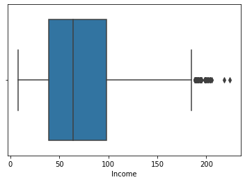

```python
sns.boxplot(x=lmdata["Income"])
```

##### CCAvg (Average spending on credit cards per month)

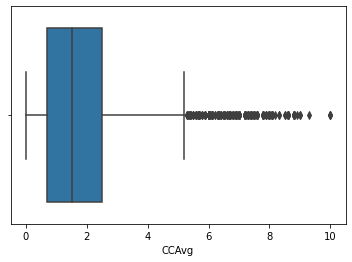

```python
sns.boxplot(x=lmdata["CCAvg"])
```

##### Age

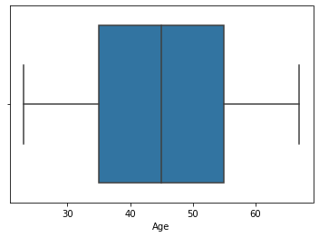

```python
sns.boxplot(x=lmdata["Age"])
```

##### Motgage

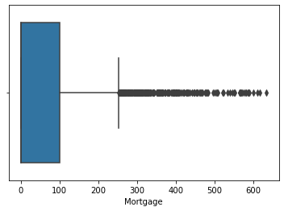

```python
sns.boxplot(x=lmdata["Mortgage"])
```

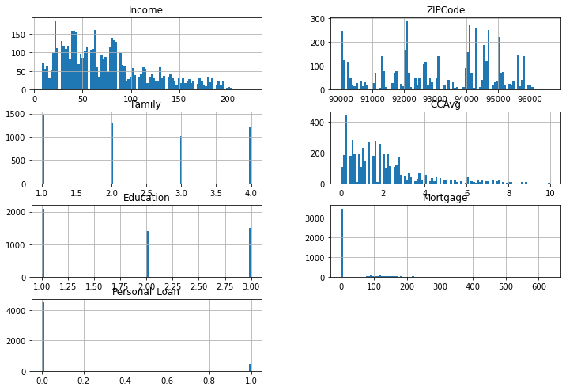

```python
ncolumns = list(lmdata)[2:9] # Excluding Outcome column which has only
lmdata[ncolumns].hist(stacked=False, bins=100, figsize=(12,30), layout=(14,2));
# Histogram of key numeric columns
```

## Multivariate Analysis

Goal is to understand patterns and relationships between the variables and to understand how they might influence the dependent variable.

#### Identifying Correlations

```python
lmdata.corr() # This will show correlation matrix
```

|  | Age | Experience | Income | ZIPCode | Family | CCAvg | Education | Mortgage | Personal_Loan | Securities_Account | CD_Account | Online | CreditCard |
| --- | --- | --- | --- | --- | --- | --- | --- | --- | --- | --- | --- | --- | --- |
| Age | 1.000000 | 0.994215 | -0.055269 | -0.030530 | -0.046418 | -0.052012 | 0.041334 | -0.012539 | -0.007726 | -0.000436 | 0.008043 | 0.013702 | 0.007681 |
| Experience | 0.994215 | 1.000000 | -0.046574 | -0.030456 | -0.052563 | -0.050077 | 0.013152 | -0.010582 | -0.007413 | -0.001232 | 0.010353 | 0.013898 | 0.008967 |
| Income | -0.055269 | -0.046574 | 1.000000 | -0.030709 | -0.157501 | 0.645984 | -0.187524 | 0.206806 | 0.502462 | -0.002616 | 0.169738 | 0.014206 | -0.002385 |
| ZIPCode | -0.030530 | -0.030456 | -0.030709 | 1.000000 | 0.027512 | -0.012188 | -0.008266 | 0.003614 | -0.002974 | 0.002422 | 0.021671 | 0.028317 | 0.024033 |
| Family | -0.046418 | -0.052563 | -0.157501 | 0.027512 | 1.000000 | -0.109275 | 0.064929 | -0.020445 | 0.061367 | 0.019994 | 0.014110 | 0.010354 | 0.011588 |
| CCAvg | -0.052012 | -0.050077 | 0.645984 | -0.012188 | -0.109275 | 1.000000 | -0.136124 | 0.109905 | 0.366889 | 0.015086 | 0.136534 | -0.003611 | -0.006689 |
| Education | 0.041334 | 0.013152 | -0.187524 | -0.008266 | 0.064929 | -0.136124 | 1.000000 | -0.033327 | 0.136722 | -0.010812 | 0.013934 | -0.015004 | -0.011014 |
| Mortgage | -0.012539 | -0.010582 | 0.206806 | 0.003614 | -0.020445 | 0.109905 | -0.033327 | 1.000000 | 0.142095 | -0.005411 | 0.089311 | -0.005995 | -0.007231 |
| Personal_Loan | -0.007726 | -0.007413 | 0.502462 | -0.002974 | 0.061367 | 0.366889 | 0.136722 | 0.142095 | 1.000000 | 0.021954 | 0.316355 | 0.006278 | 0.002802 |
| Securities_Account | -0.000436 | -0.001232 | -0.002616 | 0.002422 | 0.019994 | 0.015086 | -0.010812 | -0.005411 | 0.021954 | 1.000000 | 0.317034 | 0.012627 | -0.015028 |
| CD_Account | 0.008043 | 0.010353 | 0.169738 | 0.021671 | 0.014110 | 0.136534 | 0.013934 | 0.089311 | 0.316355 | 0.317034 | 1.000000 | 0.175880 | 0.278644 |
| Online | 0.013702 | 0.013898 | 0.014206 | 0.028317 | 0.010354 | -0.003611 | -0.015004 | -0.005995 | 0.006278 | 0.012627 | 0.175880 | 1.000000 | 0.004210 |
| CreditCard | 0.007681 | 0.008967 | -0.002385 | 0.024033 | 0.011588 | -0.006689 | -0.011014 | -0.007231 | 0.002802 | -0.015028 | 0.278644 | 0.004210 | 1.000000 |

```python
# However we want to see correlation in graphical representation so below is function for that
def plot_corr(lmdata, size=11):
    corr = lmdata.corr()
    fig, ax = plt.subplots(figsize=(size, size))
    ax.matshow(corr)
    plt.xticks(range(len(corr.columns)), corr.columns)
    plt.yticks(range(len(corr.columns)), corr.columns)
    for (i, j), z in np.ndenumerate(corr):
        ax.text(j, i, '{:0.1f}'.format(z), ha='center', va='center')
```

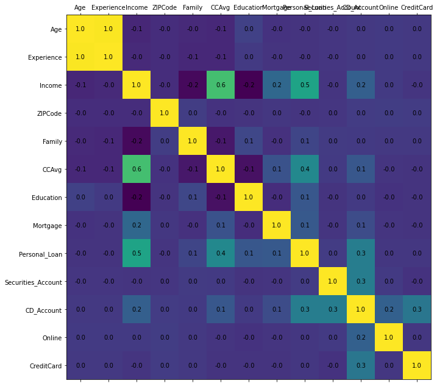

```python
plot_corr(lmdata)
```

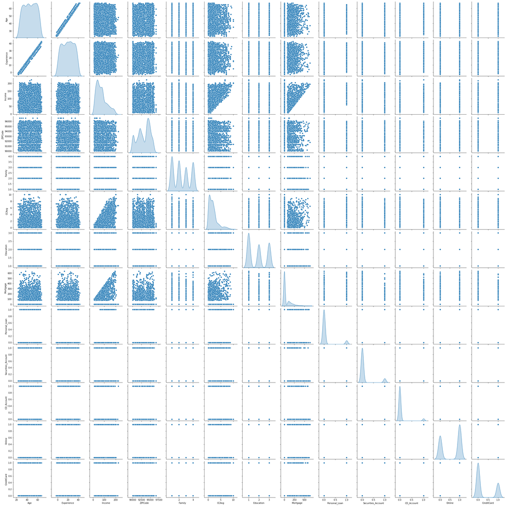

```python
sns.pairplot(lmdata,diag_kind='kde')
```

## Data Preparation

```python
# Replace values in the experience column that are less than 0 with the mean
print('Number of entries with values less than 0 : ' + str((lmdata['Experience'] < 0).sum()))
```

[output not shown]

```python
average_experience = round(lmdata['Experience'].mean())

for i in lmdata['Experience']:
    if (i < 0):
        lmdata['Experience'] = lmdata['Experience'].replace(to_replace=i, value=average_experience)

#lmdata['Experience'].where(lmdata['Experience'] < 0, average_experience, inplace=True)
```

```python
(lmdata['Experience'] < 0).sum()
```

```
0
```

```python
n_true = len(lmdata.loc[lmdata['Personal_Loan'] == 1])
n_false = len(lmdata.loc[lmdata['Personal_Loan'] == 0])
print("Number of true cases: {0} ({1:2.2f}%)".format(n_true, (n_true / (n_true + n_false)) * 100 ))
print("Number of false cases: {0} ({1:2.2f}%)".format(n_false, (n_false / (n_true + n_false)) * 100))
```

```
Number of true cases: 480 (9.60%)
Number of false cases: 4520 (90.40%)
```

So we have 9.6% people in current data who convert to take personal loans.

Its an ok distribution of conversion rate in the data

## SPlitting the data

We will use 70% of data for training and 30% for testing

```python
from sklearn.model_selection import train_test_split

X = lmdata.drop(["Personal_Loan",], axis=1)     # Predictor feature columns (8 X m)
Y = lmdata['Personal_Loan']   # Predicted class (1=True, 0=False) (1 X m)

x_train, x_test, y_train, y_test = train_test_split(X, Y, test_size=0.3, random_state=1)
# 1 is just any random seed number

x_train.head()
```

|  | Age | Experience | Income | ZIPCode | Family | CCAvg | Education | Mortgage | Securities_Account | CD_Account | Online | CreditCard |
| --- | --- | --- | --- | --- | --- | --- | --- | --- | --- | --- | --- | --- |
| 1334 | 47 | 22 | 35 | 94304 | 2 | 1.3 | 1 | 0 | 0 | 0 | 1 | 0 |
| 4768 | 38 | 14 | 39 | 93118 | 1 | 2.0 | 2 | 0 | 0 | 0 | 1 | 0 |
| 65 | 59 | 35 | 131 | 91360 | 1 | 3.8 | 1 | 0 | 0 | 0 | 1 | 1 |
| 177 | 29 | 3 | 65 | 94132 | 4 | 1.8 | 2 | 244 | 0 | 0 | 0 | 0 |
| 4489 | 39 | 13 | 21 | 95518 | 3 | 0.2 | 2 | 0 | 0 | 0 | 1 | 0 |

Checking split of data

```python
print("{0:0.2f}% data is in training set".format((len(x_train)/len(lmdata.index)) * 100))
print("{0:0.2f}% data is in test set".format((len(x_test)/len(lmdata.index)) * 100))
```

```
70.00% data is in training set
30.00% data is in test set
```

```python
#Now lets check perosnal loan  True/False ratio in split data
print("Original Personal Loan True  Values    : {0} ({1:0.2f}%)".format(len(lmdata.loc[lmdata['Personal_Loan'] == 1]), (len(lmdata.loc[lmdata['Personal_Loan'] == 1])/len(lmdata.index)) * 100))
print("Original Personal Loan False Values   : {0} ({1:0.2f}%)".format(len(lmdata.loc[lmdata['Personal_Loan'] == 0]), (len(lmdata.loc[lmdata['Personal_Loan'] == 0])/len(lmdata.index)) * 100))
print("")
print("Training Personal Loan True Values    : {0} ({1:0.2f}%)".format(len(y_train[y_train[:] == 1]), (len(y_train[y_train[:] == 1])/len(y_train)) * 100))
print("Training Personal Loan False Values   : {0} ({1:0.2f}%)".format(len(y_train[y_train[:] == 0]), (len(y_train[y_train[:] == 0])/len(y_train)) * 100))
print("")
print("Test Personal Loan True Values        : {0} ({1:0.2f}%)".format(len(y_test[y_test[:] == 1]), (len(y_test[y_test[:] == 1])/len(y_test)) * 100))
print("Test Personal Loan False Values       : {0} ({1:0.2f}%)".format(len(y_test[y_test[:] == 0]), (len(y_test[y_test[:] == 0])/len(y_test)) * 100))
print("")
```

```
Original Personal Loan True  Values    : 480 (9.60%)
Original Personal Loan False Values   : 4520 (90.40%)

Training Personal Loan True Values    : 331 (9.46%)
Training Personal Loan False Values   : 3169 (90.54%)

Test Personal Loan True Values        : 149 (9.93%)
Test Personal Loan False Values       : 1351 (90.07%)
```

```python
x_train.head(10)
```

|  | Age | Experience | Income | ZIPCode | Family | CCAvg | Education | Mortgage | Securities_Account | CD_Account | Online | CreditCard |
| --- | --- | --- | --- | --- | --- | --- | --- | --- | --- | --- | --- | --- |
| 1334 | 47 | 22 | 35 | 94304 | 2 | 1.3 | 1 | 0 | 0 | 0 | 1 | 0 |
| 4768 | 38 | 14 | 39 | 93118 | 1 | 2.0 | 2 | 0 | 0 | 0 | 1 | 0 |
| 65 | 59 | 35 | 131 | 91360 | 1 | 3.8 | 1 | 0 | 0 | 0 | 1 | 1 |
| 177 | 29 | 3 | 65 | 94132 | 4 | 1.8 | 2 | 244 | 0 | 0 | 0 | 0 |
| 4489 | 39 | 13 | 21 | 95518 | 3 | 0.2 | 2 | 0 | 0 | 0 | 1 | 0 |
| 3889 | 26 | 0 | 19 | 93014 | 1 | 0.1 | 2 | 121 | 0 | 0 | 1 | 0 |
| 1922 | 39 | 15 | 25 | 93023 | 1 | 1.4 | 3 | 0 | 0 | 0 | 0 | 0 |
| 26 | 40 | 16 | 83 | 95064 | 4 | 0.2 | 3 | 0 | 0 | 0 | 0 | 0 |
| 2458 | 46 | 20 | 72 | 93108 | 2 | 0.8 | 3 | 0 | 0 | 0 | 1 | 1 |
| 525 | 64 | 38 | 79 | 94024 | 2 | 2.8 | 1 | 179 | 0 | 0 | 0 | 0 |

## Logistic Regression

```python
from sklearn import metrics

from sklearn.linear_model import LogisticRegression

# Fit the model on train
model = LogisticRegression(solver="liblinear", random_state=1)
model.fit(x_train, y_train)
#predict on test
y_predict = model.predict(x_test)


coef_lmdata = pd.DataFrame(model.coef_)
coef_lmdata['intercept'] = model.intercept_
print(coef_lmdata)
```

```
          0       1         2         3         4         5        6        7  \
0  0.001819 -0.0049  0.036103 -0.000066  0.014945  0.009235  0.01615  0.00083

         8         9        10        11  intercept
0  0.00052  0.004561 -0.000129 -0.000021  -0.000062
```

```python
model_score = model.score(x_test, y_test)
print(model_score)
```

```
0.9073333333333333
```

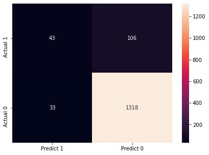

```python
cm=metrics.confusion_matrix(y_test, y_predict, labels=[1, 0])
lmdata_cm = pd.DataFrame(cm, index = [i for i in ["Actual 1"," Actual 0"]],
                  columns = [i for i in ["Predict 1","Predict 0"]])
plt.figure(figsize = (7,5))
sns.heatmap(lmdata_cm, annot=True,fmt='g')
plt.show()
```

- The confusion matrix
- True Positives (TP): we correctly predicted that they convert to take personal loans 43
- True Negatives (TN): we correctly predicted that they didn't take personal loan 1318
- False Positives (FP): we incorrectly predicted that they did take personal loan (a "Type I error") 33 Falsely predict positive Type I error
- False Negatives (FN): we incorrectly predicted that they didn't take personal loan (a "Type II error") 106 Falsely predict negative Type II error

## Decision Tree Model

The Decision tree model will be built using DecisionTreeClassifier function and utilize default 'gini' criteria to split. Other option include 'entropy'

```python
from sklearn.tree import DecisionTreeClassifier
from sklearn import tree
from sklearn.model_selection import train_test_split

X = lmdata.drop(["Personal_Loan"], axis=1)     # Predictor feature columns (8 X m)
Y = lmdata['Personal_Loan']   # Predicted class (1=True, 0=False) (1 X m)

x_train, x_test, y_train, y_test = train_test_split(X, Y, test_size=0.3, random_state=1)
# 1 is just any random seed number
```

```python
dTree = DecisionTreeClassifier(criterion = 'gini', random_state=1)
dTree.fit(x_train, y_train)
```

```
DecisionTreeClassifier(random_state=1)
```

## Scoring our Decision Tree

```python
print("Accuracy on training set : ",dTree.score(x_train, y_train))
print("Accuracy on test set : ",dTree.score(x_test, y_test))
```

```
Accuracy on training set :  1.0
Accuracy on test set :  0.98
```

```python
## Function to create confusion matrix
def make_confusion_matrix(model,y_actual,labels=[1, 0]):
    '''
    model : classifier to predict values of X
    y_actual : ground truth

    '''
    y_predict = model.predict(x_test)
    cm=metrics.confusion_matrix( y_actual, y_predict, labels=[0, 1])
    df_cm = pd.DataFrame(cm, index = [i for i in ["Actual - No","Actual - Yes"]],
                  columns = [i for i in ['Predicted - No','Predicted - Yes']])
    group_counts = ["{0:0.0f}".format(value) for value in
                cm.flatten()]
    group_percentages = ["{0:.2%}".format(value) for value in
                         cm.flatten()/np.sum(cm)]
    labels = [f"{v1}\n{v2}" for v1, v2 in
              zip(group_counts,group_percentages)]
    labels = np.asarray(labels).reshape(2,2)
    plt.figure(figsize = (10,7))
    sns.heatmap(df_cm, annot=labels,fmt='')
    plt.ylabel('True label')
    plt.xlabel('Predicted label')
```

```python
##  Function to calculate recall score
def get_recall_score(model):
    '''
    model : classifier to predict values of X

    '''
    pred_train = model.predict(x_train)
    pred_test = model.predict(x_test)
    print("Recall on training set : ",metrics.recall_score(y_train,pred_train))
    print("Recall on test set : ",metrics.recall_score(y_test,pred_test))
```

## Confusion Matrix

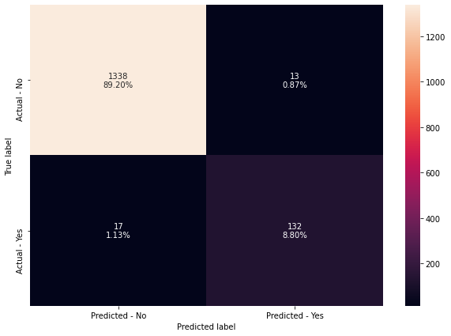

```python
make_confusion_matrix(dTree,y_test)
```

```python
# Recall on train and test
get_recall_score(dTree)
```

```
Recall on training set :  1.0
Recall on test set :  0.8859060402684564
```

## Visualizing the Decision Tree

```python
feature_names = list(X.columns)
print(feature_names)
```

```
['Age', 'Experience', 'Income', 'ZIPCode', 'Family', 'CCAvg', 'Education', 'Mortgage', 'Securities_Account', 'CD_Account', 'Online', 'CreditCard']
```

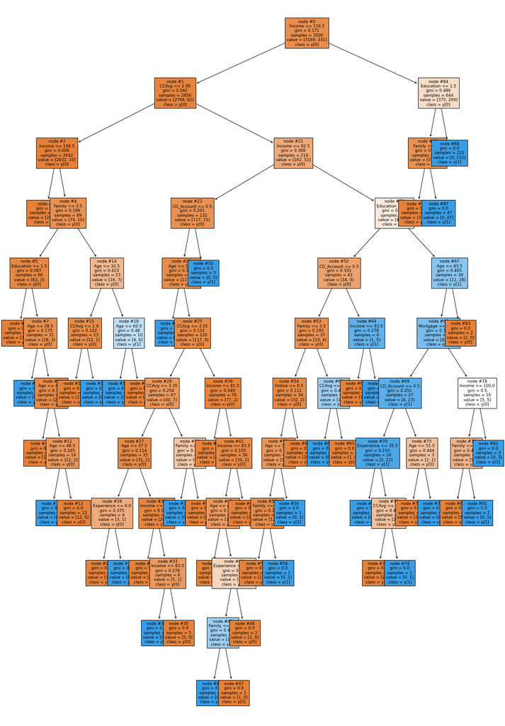

```python
plt.figure(figsize=(20,30))
tree.plot_tree(dTree,feature_names=feature_names,filled=True,fontsize=9,node_ids=True,class_names=True)
plt.show()
```

```python
# Text report showing the rules of a decision tree -

print(tree.export_text(dTree,feature_names=feature_names,show_weights=True))
```

```
|--- Income <= 116.50
|   |--- CCAvg <= 2.95
|   |   |--- Income <= 106.50
|   |   |   |--- weights: [2553.00, 0.00] class: 0
|   |   |--- Income >  106.50
|   |   |   |--- Family <= 3.50
|   |   |   |   |--- Education <= 1.50
|   |   |   |   |   |--- weights: [35.00, 0.00] class: 0
|   |   |   |   |--- Education >  1.50
|   |   |   |   |   |--- Age <= 28.50
|   |   |   |   |   |   |--- weights: [0.00, 1.00] class: 1
|   |   |   |   |   |--- Age >  28.50
|   |   |   |   |   |   |--- Age <= 41.50
|   |   |   |   |   |   |   |--- weights: [16.00, 0.00] class: 0
|   |   |   |   |   |   |--- Age >  41.50
|   |   |   |   |   |   |   |--- Age <= 48.50
|   |   |   |   |   |   |   |   |--- weights: [0.00, 2.00] class: 1
|   |   |   |   |   |   |   |--- Age >  48.50
|   |   |   |   |   |   |   |   |--- weights: [12.00, 0.00] class: 0
|   |   |   |--- Family >  3.50
|   |   |   |   |--- Age <= 32.50
|   |   |   |   |   |--- CCAvg <= 2.40
|   |   |   |   |   |   |--- weights: [12.00, 0.00] class: 0
|   |   |   |   |   |--- CCAvg >  2.40
|   |   |   |   |   |   |--- weights: [0.00, 1.00] class: 1
|   |   |   |   |--- Age >  32.50
|   |   |   |   |   |--- Age <= 60.00
|   |   |   |   |   |   |--- weights: [0.00, 6.00] class: 1
|   |   |   |   |   |--- Age >  60.00
|   |   |   |   |   |   |--- weights: [4.00, 0.00] class: 0
|   |--- CCAvg >  2.95
|   |   |--- Income <= 92.50
|   |   |   |--- CD_Account <= 0.50
|   |   |   |   |--- Age <= 26.50
|   |   |   |   |   |--- weights: [0.00, 1.00] class: 1
|   |   |   |   |--- Age >  26.50
|   |   |   |   |   |--- CCAvg <= 3.55
|   |   |   |   |   |   |--- CCAvg <= 3.35
|   |   |   |   |   |   |   |--- Age <= 37.50
|   |   |   |   |   |   |   |   |--- Experience <= 9.00
```

[output cut: 78 more lines]

```
|   |   |   |   |   |   |   |   |--- weights: [5.00, 0.00] class: 0
|   |   |   |   |   |   |   |--- Family >  2.50
|   |   |   |   |   |   |   |   |--- weights: [0.00, 2.00] class: 1
|   |   |   |   |   |   |--- Income >  100.00
|   |   |   |   |   |   |   |--- weights: [0.00, 3.00] class: 1
|   |   |   |   |--- Age >  63.50
|   |   |   |   |   |--- weights: [2.00, 0.00] class: 0
|--- Income >  116.50
|   |--- Education <= 1.50
|   |   |--- Family <= 2.50
|   |   |   |--- weights: [375.00, 0.00] class: 0
|   |   |--- Family >  2.50
|   |   |   |--- weights: [0.00, 47.00] class: 1
|   |--- Education >  1.50
|   |   |--- weights: [0.00, 222.00] class: 1
```

```python
# importance of features in the tree building ( The importance of a feature is computed as the
#(normalized) total reduction of the criterion brought by that feature. It is also known as the Gini importance )

print (pd.DataFrame(dTree.feature_importances_, columns = ["Imp"], index = x_train.columns).sort_values(by = 'Imp', ascending = False))
```

```
                         Imp
Education           0.401465
Income              0.308336
Family              0.167368
CCAvg               0.049712
Age                 0.035656
CD_Account          0.025711
Experience          0.008175
Mortgage            0.003014
Online              0.000561
ZIPCode             0.000000
Securities_Account  0.000000
CreditCard          0.000000
```

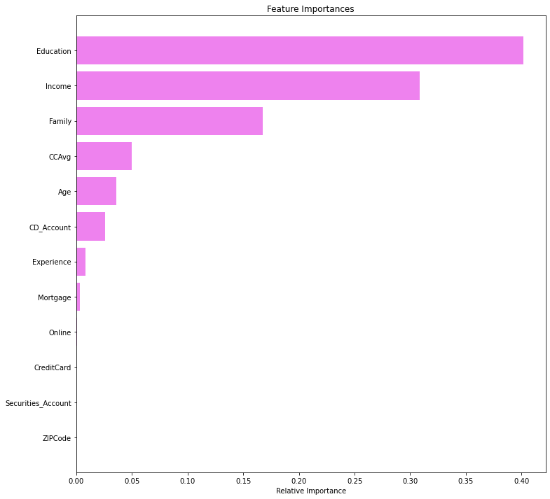

```python
importances = dTree.feature_importances_
indices = np.argsort(importances)

plt.figure(figsize=(12,12))
plt.title('Feature Importances')
plt.barh(range(len(indices)), importances[indices], color='violet', align='center')
plt.yticks(range(len(indices)), [feature_names[i] for i in indices])
plt.xlabel('Relative Importance')
plt.show()
```

- According to the decision tree model, education, income and family are the top 3 predictors of personal loan conversion

### Recommendations

As the model predicts Eduction, income and family as the top predictors of whether a customer will buy a personal loan, I believe one of the ways to tackle this is to group the custormers High target Profile Clients, Average and Low target profiles.

- High target customers are customers with high or advanced level of eduction, high income and close to a large family size.
- The average target cursomers would also have high level of education, average base salary and avserage family size which is about 2.
- Low target Profile would be the customers with Lower income, undergrads, with and average sized family and low spending.